# EasyVisa Project

### Observations for case_status vs requires_job_training

- Per the stacked barplot, visa employees that needed job training (approx 65%) and visa employees that didn't need job training (approx 65%) visas were certified.
- The visas certified seem to be identical regardless regardless of the training status for the visa employee.
- Per the distribution plot, most of the applications (approx 83%) were for employees that didn't need training.

```python
# case_status vs no_of_employees cross tabulation table
sorter = df1["case_status"].value_counts().index[-1]
pd.crosstab(df1["no_of_employees"], df1["case_status"], margins=True).sort_values(by = sorter, ascending=False)
```

| case_status no_of_employees | Certified | Denied | All |
| --- | --- | --- | --- |
| All | 17018 | 8462 | 25480 |
| 1476 | 6 | 9 | 15 |
| 169 | 5 | 9 | 14 |
| 499 | 1 | 8 | 9 |
| 1290 | 3 | 8 | 11 |
| ... | ... | ... | ... |
| 4887 | 1 | 0 | 1 |
| 4888 | 1 | 0 | 1 |
| 4889 | 2 | 0 | 2 |
| 4890 | 1 | 0 | 1 |
| 4066 | 2 | 0 | 2 |

7106 rows × 3 columns

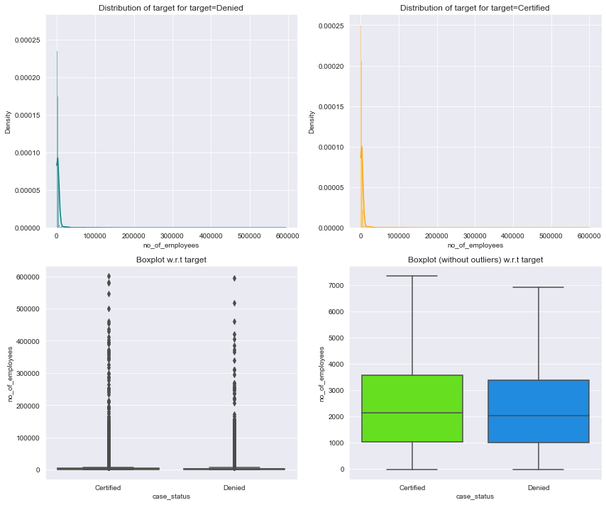

```python
# case_status vs no_of_employees distribution plot
distribution_plot_wrt_target(df1, "no_of_employees", "case_status")
```

### Observations for case_status vs no_of_employees

- Per the boxplot with outliers, there are numerous outliers in number of employees a company had for visa applications that got certified or denied.
- Per the boxplot with outliers removed, the high end for number of employees at a company that got certified is approx 7500 employees. For the high end for number of employees at a company that got denied is approx 7000 employees.

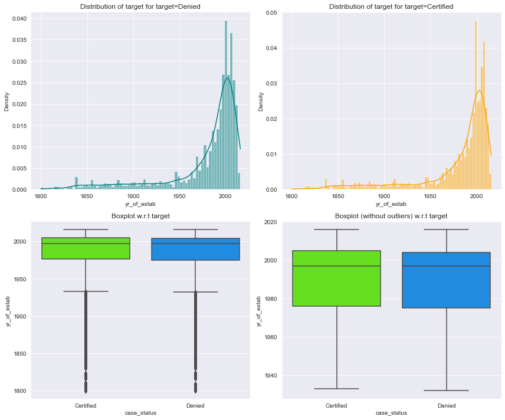

```python
# case_status vs yr_of_estab distribution plot
distribution_plot_wrt_target(df1, "yr_of_estab", "case_status")
```

### Observations for case_status vs yr_of_estab

- Per the boxplot with outliers, there are numerous outliers for year the company was established visa applications that got certified or denied.
- Per the boxplot with outliers removed, the high end for year the company was established that got certified is approx 2016. For the high end for number of employees at a company that got denied is also approx 2016.
- Certified and Denied boxplots (regardless of outliers) looking at year company applying for visa was established looks to be identical.

```
case_status           Certified  Denied    All
region_of_employment
All                       17018    8462  25480
Northeast                  4526    2669   7195
West                       4100    2486   6586
South                      4913    2104   7017
Midwest                    3253    1054   4307
Island                      226     149    375
------------------------------------------------------------------------------------------------------------------------
```

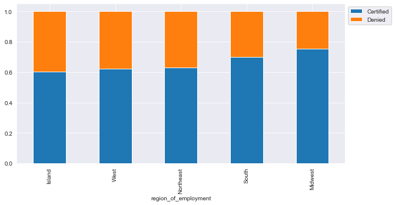

```python
# case_status vs region_of_employment stacked barplot
stacked_barplot(df1, "region_of_employment", "case_status")
```

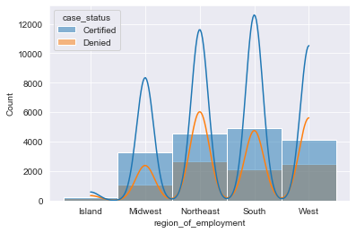

```python
# case_status vs region_of_employment distribution plot
sns.histplot(df1, x = "region_of_employment", hue = "case_status", kde = True)
```

### Observations for case_status vs region_of_employment

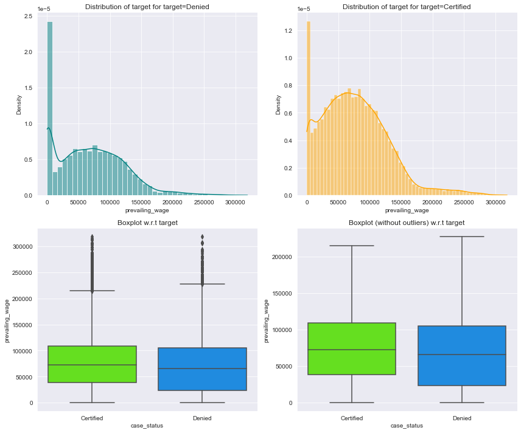

```python
# case_status vs prevailing_wage distribution plot
distribution_plot_wrt_target(df1, "prevailing_wage", "case_status")
```

### Observations for case_status vs prevailing_wage

```
case_status   Certified  Denied    All
unit_of_wage
All               17018    8462  25480
Year              16047    6915  22962
Hour                747    1410   2157
Week                169     103    272
Month                55      34     89
------------------------------------------------------------------------------------------------------------------------
```

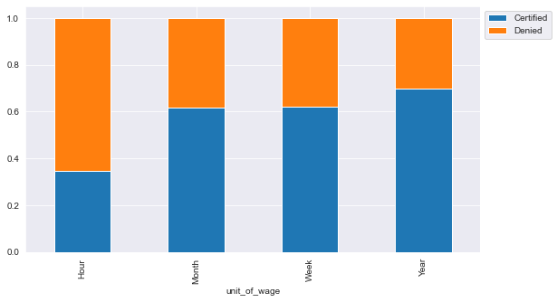

```python
# case_status vs unit_of_wage stacked barplot
stacked_barplot(df1, "unit_of_wage", "case_status")
```

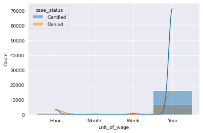

```python
# case_status vs unit_of_wage distribution plot
sns.histplot(df1, x = "unit_of_wage", hue = "case_status", kde = True)
```

### Observations for case_status vs unit_of_wage

```
case_status         Certified  Denied    All
full_time_position
All                     17018    8462  25480
Y                       15163    7610  22773
N                        1855     852   2707
------------------------------------------------------------------------------------------------------------------------
```

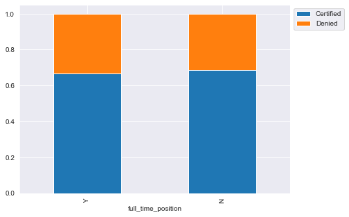

```python
# case_status vs full_time_position stacked barplot
stacked_barplot(df1, "full_time_position", "case_status")
```

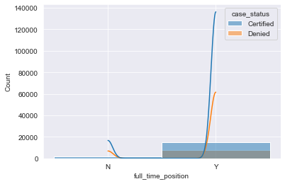

```python
# case_status vs full_time_position distribution plot
sns.histplot(df1, x = "full_time_position", hue = "case_status", kde = True)
```

### Observations for case_status vs full_time_position

- Per the stacked barplot, visas for the position being full time (approx 66%) or part time (approx 67%) were certified.
- Regardless of position type, the certification rate looks identical.
- Per the distribution plot, most of the applications (approx 91%) are for full time positions.

**Leading Questions**:

1. Those with higher education may want to travel abroad for a well-paid job. Does education play a role in Visa certification?
2. How does the visa status vary across different continents?
3. Experienced professionals might look abroad for opportunities to improve their lifestyles and career development. Does work experience influence visa status?
4. In the United States, employees are paid at different intervals. Which pay unit is most likely to be certified for a visa?
5. The US government has established a prevailing wage to protect local talent and foreign workers. How does the visa status change with the prevailing wage?

### Question 1 - Those with higher education may want to travel abroad for a well-paid job. Does education play a role in Visa certification?

```
case_status            Certified  Denied    All
education_of_employee
All                        17018    8462  25480
Bachelor's                  6367    3867  10234
High School                 1164    2256   3420
Master's                    7575    2059   9634
Doctorate                   1912     280   2192
------------------------------------------------------------------------------------------------------------------------
```

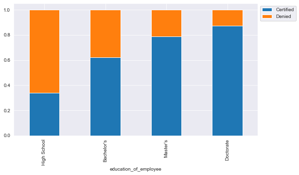

```
Per the stacked barplot, the higher education level a visa employee has,
the better the chances of the visa getting certified
```

```python
# case_status vs education_of_employee stacked barplot
stacked_barplot(df1, "education_of_employee", "case_status")

print("Per the stacked barplot, the higher education level a visa employee has, \nthe better the chances of the visa getting certified")
```

### Question 2 - How does the visa status vary across different continents?

```
case_status    Certified  Denied    All
continent
All                17018    8462  25480
Asia               11012    5849  16861
North America       2037    1255   3292
Europe              2957     775   3732
South America        493     359    852
Africa               397     154    551
Oceania              122      70    192
------------------------------------------------------------------------------------------------------------------------
```

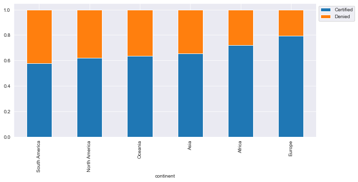

```
Per the stacked barplot, Europe has the highest certification rate followed by Africa and Asia rounding the top 3.
All continents have a better than 50% certification rate.
```

```python
# case_status vs continent stacked barplot
stacked_barplot(df1, "continent", "case_status")

print("Per the stacked barplot, Europe has the highest certification rate followed by Africa and Asia rounding the top 3. \nAll continents have a better than 50% certification rate.")
```